# Practice1

## Практика 1. Наивная вероятность. Вероятностное пространство.

[figure not shown]

```python
from IPython.display import Image
Image(filename='data/mem.jpg', width=700)
```

### Основные формулы

$$P = \frac{m}{n} = \frac{\textrm{число благоприятных исходов}}{\textrm{число всех исходов}}$$

Число способов выбрать $k$ объектов из $n$ различных объектов. $$C_{n}^{k} = \frac{n!}{k!(n-k)!}$$

Число перестановок $$P_n = n!$$

**Пример вероятностного пространства**

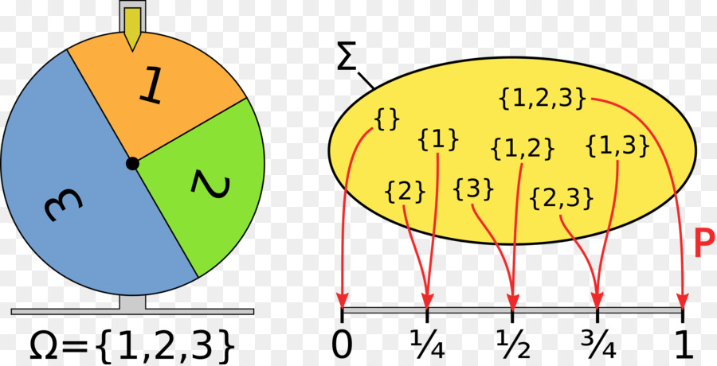

```python
Image(filename='data/space.jpg', width=500)
```

### Задачи на пару

**Задача 0.**

У нас есть правильный кубик. Какова вероятность выпадения:

- При двух бросках, оба раза выпала единица
- Сумма 2х бросков - 7
- Сумма 3х бросков - 16

**Задача 1. (Амазон)**

У нас есть 12 идентичных черных носков и 12 идентичных белых носков. Мы произвольно выбрали пару. Какая вероятность, что носки образовали цветную пару?

**Задача 2 (1 балл).**

В программе к экзамену по теории вероятностей 75 вопросов. Студент знает 50 из них. В билете 3 вопроса. Найдите вероятность того, что студент знает хотя бы два вопроса из вытянутого им билета.

**Задача 3. (TED)**

За закрытой дверью сидят два ребенка. Они могут быть равновероятно девочкой и мальчиком. Какова вероятность, что там 2 мальчика, если:

a) там точно есть один мальчик

b) мы слышали крик одного ребенка за дверью, и этот крик точно принадлежал мальчику.

c) мы слишали крик одного или двух детей за дверью, и услышанный крик точно принадлежит мальчику (а как же иначе, девочки обычно не кричат).

P.S. Любой ребенок может кричать или не кричать с равной вероятностью.

**Задача 4.**

У нас есть 3 карточки: одна чисто красная, вторая чисто синяя, третья - одна грань красная, другая - синяя. Мы взяли рандомную карту. Она оказалась синяя. Какова вероятность того, что ее обратная грань - синяя?

**Задача 5. (Google) (Если успеем)**

Пришелец сел на землю. Каждый день он с равной вероятностью может умереть, дуплицироваться (станет 2 пришельца), триплецироваться (станет 3 пришельца), и ничего не делать. Какова вероятность, что раса пришельцев самоуничтожится?

## ДЗ

**Задача 1. (1 балл)**

Партия продукции состоит из десяти изделий, среди которых два изделия дефектные. Какова вероятность того, что из пяти отобранных наугад и проверенных изделий:

- ровно одно изделие дефектное;
- ровно два изделия дефектные;
- хотя бы одно изделие дефектное?

**Задача 2 (1 балл).**

На полке в случайном порядке расставлено 40 книг, среди которых находится трехтомник А. С. Пушкина. Найти вероятность того, что эти тома стоят в порядке возрастания слева направо (но не обязательно рядом).

**Задача 3 (1 балл). (Парадокс дней рождений)**

Найти вероятность того, что в классе из 23 человек, не менее двух учеников родились в один день.

**Задача 4 (1 балл). (Amazon)**

Есть кубик с гранями (1,2,3,4,5,6) и кубик, грани которого мы не видим. Известно, что при подбрасывании пары кубиков, выпадение любой возможной суммы равновероятно. Какие числа написаны на гранях неправильного кубика.

**Задача 5 (1 балл). (Boy or Girl paradox)**

В семье есть 2 ребенка. Пол каждого ребенка - равновероятен. Какова вероятность того, что в семье есть девочка, если

- В семье точно есть один мальчик
- В семье есть мальчик, который родился во Вторник.

### Гробы

**Гроб 1 (1 балл)**

Ребята решили сыграть в тайного санту. Они написали свои имена на бумажках и сложили в шляпу, а сейчас вытягивают имена человека, кому они будут дарить подарок. Какова вероятность того, что никто не вытянет свое же имя?

**Гроб 2** Из чисел $\{1, 2, \ldots, N\}$ случайно выбирается число $a$. Найти вероятность $p_N$ того, что:

- (а)**(0.5 балл)** число $a$ не делится ни на $a_1$ ни на $a_2$, где $a_1$ и $a_2$ -- фиксированные натуральные взаимно простые числа;
- (b)**(1 балла)** число $a$ не делится ни на какое из чисел $a_1, a_2, \ldots, a_k$, где числа $a_i$ -- натуральные и попарно взаимно простые.

Найти $\lim_{N\rightarrow\infty} p_N$ в случаях (a) и (b).

**Гроб 3 (1 балл)**

В данной задаче нужно прислать ссылку на посылку с успешно защитанным решением.

https://codeforces.com/problemset/problem/312/B

**Гроб 4 (2 балла)**

Алиса и Боб подбрасывают правильную монетку и получают некоторую последовательность из орлов и решек. Мы хотим придумать такую игру, чтобы Алиса выиграла с вероятностью $p$, а Боб вероятностью $1-p$. Придумайте правила такой игры.

Пояснение, например мы хотим, чтобы Алиса выиграла с вероятностью $\frac{3}{4}$, тогда мы устанавливаем правила, что если в за два хода мы получили хотя бы один орел, то тогда Алиса выигрывает.

Замечание: $p$ может быть иррациональным.

## Мотивация

[Зачем нужна теория вероятностей](https://habr.com/ru/company/yasno_tv/blog/298898/)

[Ускорение кода с помощью вероятности](https://habr.com/ru/company/yandex/blog/214745/)

[Тервер для программистов](https://www.youtube.com/watch?v=zaOptBoqmUg)

### Видеоматериалы (курс со Stepik)

Чтобы получить доступ к видео, нужно создать аккаунт на stepik.org, а потом вступить в [курс "Теория вероятности" от CSC](https://stepik.org/course/3089)

[Основы комбинаторики](https://stepik.org/lesson/48661/step/1)

[Введение в вероятность](https://stepik.org/lesson/48659/step/3)

[Вероятностные пространства](https://stepik.org/lesson/48660/step/1)

### Теория (курс Черновой)

[Основы комбинаторики](https://nsu.ru/mmf/tvims/chernova/tv/lec/node3.html#SECTION000210)

[Элементарная теория вероятностей](https://nsu.ru/mmf/tvims/chernova/tv/lec/node4.html#SECTION000220)